# Match Report

## Game summary

```
## Match summary:
## Date: 2019-10-27
## League: Friendlies Echidnas 2019
## Teams: Echidnas Women’s 2019
##        vs
##        Short Men 2019
## Result: 1-4 (7-25, 12-25, 13-25, 15-25, 25-19)
## Duration: unknown
```

## Full Statistics

|  | # | Player | STARTERS 1 | STARTERS 2 | STARTERS 3 | STARTERS 4 | STARTERS 5 | POINTS Pts | POINTS BP | POINTS Net | RECEPTION Err | RECEPTION Ave | RECEPTION Exc% | RECEPTION Tot | SERVE Ace | SERVE Err | SERVE Tot | ATTACK Tot | ATTACK Kill | ATTACK Blocked | ATTACK Err | ATTACK Freeball | ATTACK Kill% | BLOCK Kill block | BLOCK Err | SET Ass | SET Err | DIG Good | DIG Err |
| --- | --- | --- | --- | --- | --- | --- | --- | --- | --- | --- | --- | --- | --- | --- | --- | --- | --- | --- | --- | --- | --- | --- | --- | --- | --- | --- | --- | --- | --- |
| Echidnas Women’s 2019 |  |  |  |  |  |  |  |  |  |  |  |  |  |  |  |  |  |  |  |  |  |  |  |  |  |  |  |  |  |
|  |  | Viivi Hokinen | 3 | 6 | 6 | 6 | 3 | 6 | 1 | -3 |  |  |  |  | 1 | 3 | 7 | 22 | 4 | 2 | 6 | 2 | 18 | 1 |  |  |  |  |  |
|  |  | Misha Masuda | 5 | 5 | 5 | 2 | 2 | 8 | 5 | -2 | 6 | 1.37 | 17 | 35 | 2 | 1 | 13 | 30 | 5 |  | 3 | 12 | 17 | 1 |  | 1 |  | 7 |  |
|  |  | Rebecca Flinn | 6 | 3 | 3 | 3 | 6 | 13 | 8 | 9 |  |  |  |  | 5 | 3 | 16 | 25 | 7 |  | 1 | 8 | 28 | 1 |  |  |  | 1 |  |
|  |  | Alice Agnew | 4 | 4 | 4 | 4 | 4 | 5 | 4 | -10 | 1 | 1.00 |  | 5 |  | 3 | 9 | 30 | 5 |  | 6 | 3 | 17 |  |  |  | 1 | 2 | 4 |
|  |  | Emilie Robles | L | L | L | L | L |  |  | -8 | 3 | 2.17 | 52 | 29 |  |  |  | 5 |  |  | 1 | 5 |  |  |  | 1 |  | 13 | 4 |
|  |  | Thelma Nation | 1 | 1 | 1 | 1 | 1 | 2 | 2 | -9 |  | 2.00 |  | 1 | 1 | 5 | 15 | 5 | 1 |  |  | 2 | 20 |  |  | 25 | 2 | 8 | 4 |
|  |  | Bine Jansen | 2 | 2 | 2 | 5 | 5 | 9 | 4 | -10 | 4 | 1.59 | 19 | 32 | 1 | 3 | 12 | 52 | 8 | 3 | 12 | 9 | 15 |  |  | 1 |  | 7 |  |
|  |  | Total |  |  |  |  |  | 43 | 24 | -33 | 14 | 1.66 | 26 | 102 | 10 | 18 | 72 | 169 | 30 | 5 | 29 | 41 | 18 | 3 |  | 28 | 3 | 38 | 12 |
| Short Men 2019 |  |  |  |  |  |  |  |  |  |  |  |  |  |  |  |  |  |  |  |  |  |  |  |  |  |  |  |  |  |
|  |  | Total |  |  |  |  |  | 60 | 42 | 31 |  |  |  |  | 14 | 17 | 118 | 50 | 37 | 2 | 11 | 1 | 74 | 9 |  | 35 | 1 |  |  |

| GAME | GAME Set | POINTS Pts | POINTS BP | POINTS Net | RECEPTION Err | RECEPTION Ave | RECEPTION Exc% | RECEPTION Tot | SERVE Ace | SERVE Err | SERVE Tot | ATTACK Tot | ATTACK Kill | ATTACK Blocked | ATTACK Err | ATTACK Freeball | ATTACK Kill% | BLOCK Kill block | BLOCK Err | SET Ass | SET Err | DIG Good | DIG Err |
| --- | --- | --- | --- | --- | --- | --- | --- | --- | --- | --- | --- | --- | --- | --- | --- | --- | --- | --- | --- | --- | --- | --- | --- |
|  | 1 | 4 |  | -13 | 5 | 1.30 | 13 | 23 |  | 3 | 7 | 28 | 4 |  | 5 | 9 | 14 |  |  | 5 |  | 6 | 4 |
|  | 2 | 6 | 3 | -8 | 1 | 1.67 | 19 | 21 | 2 |  | 12 | 43 | 4 | 1 | 10 | 10 | 9 |  |  | 4 |  | 10 | 3 |
|  | 3 | 7 | 3 | -11 | 5 | 1.68 | 27 | 22 | 1 | 6 | 14 | 22 | 5 | 1 | 5 | 4 | 23 | 1 |  | 5 | 1 | 1 | 1 |
|  | 4 | 9 | 5 | -7 | 2 | 1.90 | 43 | 21 | 1 | 5 | 14 | 40 | 6 | 1 | 4 | 8 | 15 | 2 |  | 6 | 1 | 11 | 4 |
|  | 5 | 17 | 13 | 6 | 1 | 1.80 | 33 | 15 | 6 | 4 | 25 | 36 | 11 | 2 | 5 | 10 | 31 |  |  | 8 | 1 | 10 |  |

| GAME | GAME Rotation | POINTS Pts | POINTS BP | POINTS Net | RECEPTION Err | RECEPTION Ave | RECEPTION Exc% | RECEPTION Tot | SERVE Ace | SERVE Err | SERVE Tot | ATTACK Tot | ATTACK Kill | ATTACK Blocked | ATTACK Err | ATTACK Freeball | ATTACK Kill% | BLOCK Kill block | BLOCK Err | SET Ass | SET Err | DIG Good | DIG Err |
| --- | --- | --- | --- | --- | --- | --- | --- | --- | --- | --- | --- | --- | --- | --- | --- | --- | --- | --- | --- | --- | --- | --- | --- |
|  | 1 | 7 | 7 | -10 | 4 | 1.56 | 26 | 27 | 1 | 5 | 15 | 44 | 4 |  | 6 | 14 | 9 | 2 |  | 4 |  | 12 | 2 |
|  | 2 | 9 | 6 | 3 | 2 | 1.60 | 20 | 10 | 3 | 2 | 11 | 18 | 6 |  | 2 | 3 | 33 |  |  | 5 |  | 1 |  |
|  | 3 | 8 | 4 | -5 | 2 | 1.64 | 36 | 14 | 2 | 3 | 11 | 29 | 6 |  | 4 | 3 | 21 |  |  | 5 | 1 | 9 | 3 |
|  | 4 | 6 |  | -4 | 2 | 1.73 | 27 | 15 |  | 3 | 9 | 20 | 6 |  | 5 | 5 | 30 |  |  | 6 |  | 4 |  |
|  | 5 | 6 | 3 | -13 | 4 | 1.15 | 5 | 20 | 3 | 4 | 12 | 25 | 2 |  | 6 | 8 | 8 | 1 |  | 3 | 1 | 7 | 4 |
|  | 6 | 7 | 4 | -4 |  | 2.44 | 50 | 16 | 1 | 1 | 14 | 33 | 6 |  | 6 | 8 | 18 |  |  | 5 | 1 | 5 | 3 |

| Skill | Interpretation | Target | Achieved |
| --- | --- | --- | --- |
| Serve | Ace to Error ratio | 0.66 | 0.56 |
| Passing | Average number of choices by setter | 2.20 | 1.66 |
| Spiking | Kill efficiency | 22.50 | 18.00 |
| Digging | on hard driven balls per set | 6.00 | 7.60 |
| Blocking | Kill blocks per set | 2.00 | 0.60 |

> Kill efficiency has improved, but the passing grade has dropped a bit. An interesting number of blocks, especially given the height difference at the net. Number of digs (on hard driven balls) is ok, some improvement could be made through better positionning.

## Side out

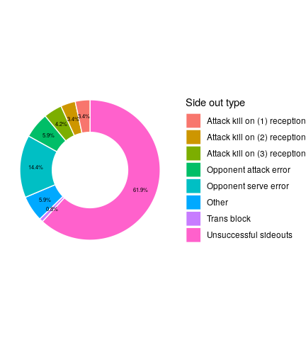

| Reception outcome/Point outcome | Point won | Point lost | Total |
| --- | --- | --- | --- |
| Error | 0% (0) | 100% (14) | 100% (14) |
| Negative/poor pass | 26% (9) | 74% (25) | 100% (34) |
| OK, no first tempo possible | 33% (9) | 67% (18) | 100% (27) |
| Perfect/positive pass | 37% (10) | 63% (17) | 100% (27) |
| Total | 27% (28) | 73% (74) | 100% (102) |

> Sideout rate has really improved, and we know have been able to kill some balls in transition, which is really good. We can improve that rate a bit more by being better positionned in defense and transitionning quickly when we know that it is not our ball to defend.

## Transition vs Serve Receive report

In transition

| attack_tempo/evaluation | Kill | In play | Blocked | Error | Total |
| --- | --- | --- | --- | --- | --- |
| Quick ball | 5% (4) | 6% (5) | 0% (0) | 1% (1) | 11% (10) |
| Fast ball | 11% (10) | 11% (10) | 1% (1) | 8% (7) | 32% (28) |
| High ball | 6% (5) | 16% (14) | 1% (1) | 2% (2) | 25% (22) |
| Freeball or unclassified | 5% (4) | 19% (17) | 0% (0) | 8% (7) | 32% (28) |
| Total | 26% (23) | 52% (46) | 2% (2) | 19% (17) | 100% (88) |

Serve receive

| attack_tempo/evaluation | Kill | In play | Blocked | Error | Total |
| --- | --- | --- | --- | --- | --- |
| Quick ball | 5% (4) | 12% (10) | 2% (2) | 4% (3) | 23% (19) |
| Fast ball | 2% (2) | 20% (16) | 1% (1) | 9% (7) | 32% (26) |
| High ball | 0% (0) | 9% (7) | 0% (0) | 1% (1) | 10% (8) |
| Freeball or unclassified | 1% (1) | 32% (26) | 0% (0) | 1% (1) | 35% (28) |
| Total | 9% (7) | 73% (59) | 4% (3) | 15% (12) | 100% (81) |

> A fairly important number of transitionning possibilities, they now need to be converted into points!

## Serving report

| evaluation/skill_type | Float serve | Jump serve | Jump-float serve | Topspin serve | Unknown serve type | Total |
| --- | --- | --- | --- | --- | --- | --- |
| Ace | 17% (8) | 0% (0) | 17% (2) | 0% (0) | 0% (0) | 14% (10) |
| Positive, opponent some attack | 19% (9) | 100% (1) | 42% (5) | 0% (0) | 40% (4) | 26% (19) |
| OK, no first tempo possible | 21% (10) | 0% (0) | 0% (0) | 0% (0) | 10% (1) | 15% (11) |
| Negative, opponent free attack | 11% (5) | 0% (0) | 33% (4) | 0% (0) | 50% (5) | 19% (14) |
| Error | 32% (15) | 0% (0) | 8% (1) | 100% (2) | 0% (0) | 25% (18) |
| Total | 100% (47) | 100% (1) | 100% (12) | 100% (2) | 100% (10) | 100% (72) |

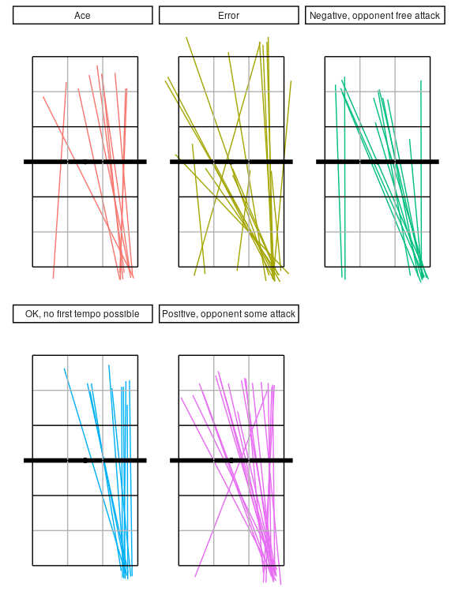

> A lot more variation on serve, which is really good. Still a few balls ending up in the middle of the courts, which we would like to avoid unless they are top spin serves.

## Setting report

| attack_tempo/Setter position | 1 | 2 | 3 | 4 | 5 | 6 | Total |
| --- | --- | --- | --- | --- | --- | --- | --- |
| Quick ball | 9% (4) | 31% (5) | 25% (7) | 25% (5) | 8% (2) | 10% (3) | 16% (26) |
| Fast ball | 30% (13) | 25% (4) | 32% (9) | 25% (5) | 29% (7) | 52% (16) | 33% (54) |
| High ball | 26% (11) | 13% (2) | 21% (6) | 25% (5) | 17% (4) | 6% (2) | 19% (30) |
| Freeball or unclassified | 35% (15) | 31% (5) | 21% (6) | 25% (5) | 46% (11) | 32% (10) | 32% (52) |
| Total | 100% (43) | 100% (16) | 100% (28) | 100% (20) | 100% (24) | 100% (31) | 100% (162) |

| attack_tempo/num_players | No block | 1 player block | 2 player block | Total |
| --- | --- | --- | --- | --- |
| Quick ball | 0% (0) | 58% (15) | 42% (11) | 100% (26) |
| Fast ball | 7% (4) | 43% (23) | 50% (27) | 100% (54) |
| High ball | 23% (7) | 40% (12) | 37% (11) | 100% (30) |
| Freeball or unclassified | 45% (5) | 55% (6) | 0% (0) | 100% (11) |
| Total | 13% (16) | 46% (56) | 40% (49) | 100% (121) |

> A good variation of tempos. No back court attack from 1, and very few slides. We can probably try to work on the slides a bit more, to create a seam in the block, or at least movement for the other team.

## Hitting report

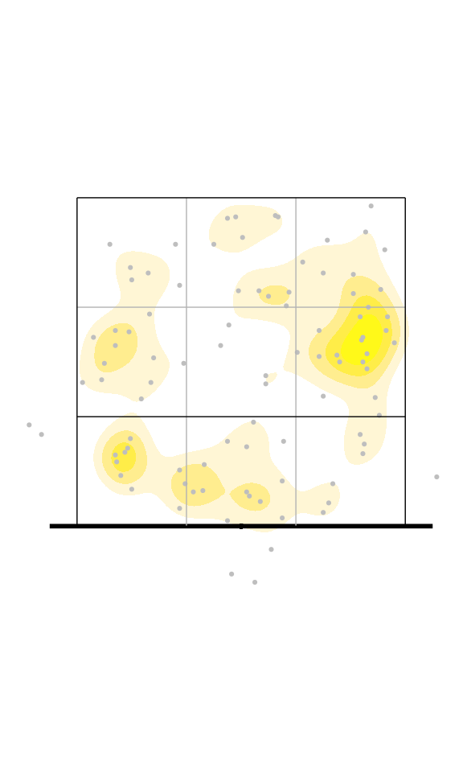

| num_players | Quick ball | Fast ball | High ball | Unclassified |
| --- | --- | --- | --- | --- |
| No block | . | 0.2500000 | 0.1428571 | 0.8 |
| 1 player block | 0.2666667 | 0.2173913 | 0.2500000 | 0.0 |
| 2 player block | 0.3636364 | 0.2222222 | 0.0909091 | . |

> Compared to the first game, much more zones have been reached. Which translated in a better hitting efficiency. We can probably aim for deeper corners, and insist in hitting more lines, especially from 4, when that is an option. A few more tips as well.

### Per Zone

| attack_tempo | Attack type | Kill | In play | Blocked | Error |
| --- | --- | --- | --- | --- | --- |
| Quick ball | A Quick | 2 | 1 | . | 1 |
|  | B Quick | . | . | 1 | . |
|  | Back-one | 2 | 3 | . | 3 |
|  | Slide | 4 | 9 | . | . |
| Fast ball | 6 (to position 2) | 4 | 7 | . | 5 |
|  | Black (or 11) | 5 | 16 | 2 | 6 |
|  | C or D (backcourt) | 1 | 1 | . | . |
|  | Pipe | 2 | 2 | . | 3 |
| High ball | 10 (backcourt) | . | 1 | . | . |
|  | 4 (to position 4) | 5 | 16 | . | 3 |
|  | 5 (to position 2) | . | 3 | 1 | . |
|  | Release Pipe | . | 1 | . | . |
| Unclassified |  | 2 | 2 | . | . |
|  | Other attack | 1 | 2 | . | 1 |
|  | Setter dump | 1 | 2 | . | . |

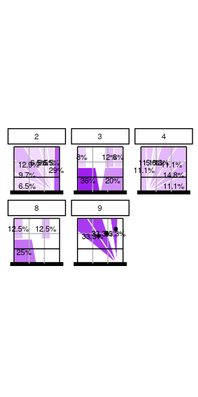

> Some real improvement in the angles chosen by the hitters, accross the board.

## Defense Gaps report

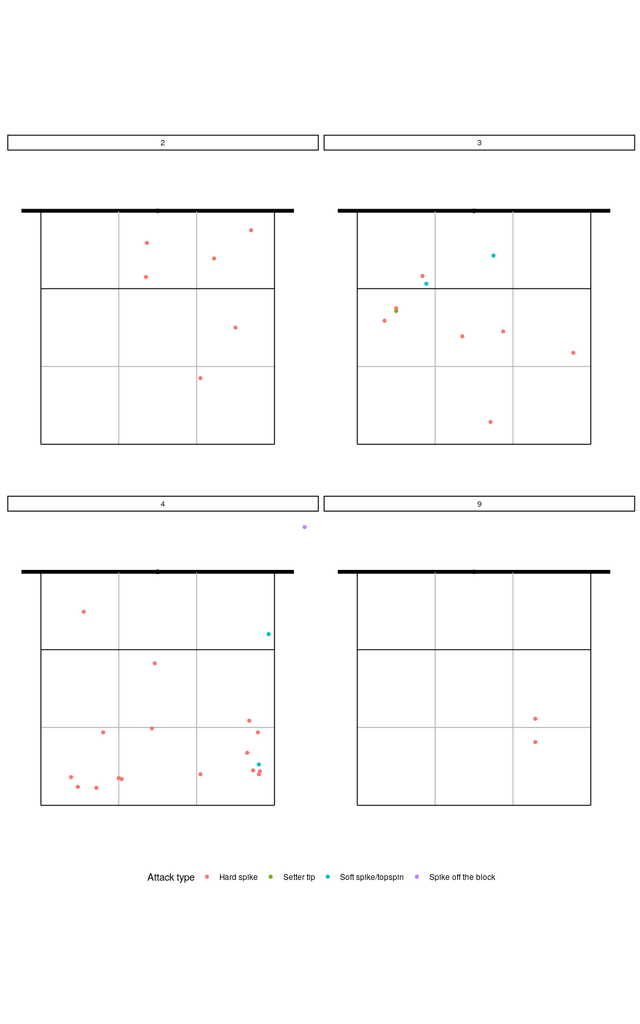

> The defense gaps displayed in these plots are probably the result of a system discipline issue, and the lack of habit of playing together. Also, given the physical difference at the net, the block cannot probably cover the right zone efficiently. To fix that we can try to respect our defense positions, and adjust to the hitting zones, especially when the other team is hitting through the middle. A lot of cross court hitting.